# Analyses

Author

Lars Schilling

Published

2026-02-20 16:20:26

# Dependencies

```r
working_dir <- "G:/Meine Ablage/Analytic_flexbility_llm_reviews/simulated_data/tvd_mi"

paper_llm_score_name <- "tvd_mi_scores_paper_llm_review_1.parquet"

paper_human_name <- "tvd_mi_scores_paper_human_review_2.parquet"
```

```r
# Flags for skipped or invalid API responses
SKIP_MESSAGE <- "Skipped cause of invalid input"
TOTAL_FAILURE_MESSAGE = "LLM call failed after multiple retries"

AMOUNT_SETTINGS <- 112 # Set to expected amount of configuration setting
AMOUNT_PAPERS <- 98 # Set to expected amount of parsed papers

COMBO_COL <- c("paper_id", "model", "temperature", "reasoning_effort", "chain_of_thought", "scope") # Set to expected combo columns
CONFIG_COL <- c("model", "hyperparameter", "chain_of_thought", "scope") # Set to expected configuration columns
BASE_SCORE_COLS <- c(
  "tpr_tvd_mi_score_1", "tpr_tvd_mi_score_2", "tpr_avg_tvd_mi_score",
  "fpr_tvd_mi_score_1", "fpr_tvd_mi_score_2", "fpr_avg_tvd_mi_score"
) # Set to expected score columns
CLEAN_SCORE_COLS <- c(
  "TPR 1", "TPR 2", "TPR AVG",
  "FPR 1", "FPR 2", "FPR AVG"
) # Set to wanted score labels
TOTAL_SCORE_COL <- "tvd_mi_score" # Set to created total score column

# Bootstrap settings
NUM_ITERATIONS <- 1000
CONFIDENCE_LVL <- 0.95

# Posthoc-test settings
###! Holmes-correction was not possible. Should I switch to bonferroni, Tuckey or try another way to run post-hoc tests?
ALPHA <- 0.05
POST_HOC_CORRECTION = "bonferroni"
```

```r
load_pkg <- function(pkg) {
  if (!require(pkg, character.only = TRUE)) {
    install.packages(pkg, dependencies = TRUE)
    library(pkg, character.only = TRUE)
  }
}

load_pkg("arrow")
load_pkg("tidyverse")
load_pkg("lme4")
load_pkg("car")
load_pkg("emmeans")
load_pkg("multcomp")
load_pkg("multcompView")
load_pkg("broom.mixed")
load_pkg("transport")
load_pkg("knitr")
load_pkg("kableExtra")
load_pkg("cowplot")
load_pkg("ggtext")
```

# Load data

```r
full_path_paper_llm <- file.path(working_dir, paper_llm_score_name)


paper_llm_score <- read_parquet(full_path_paper_llm,
                                as_data_frame = TRUE, mmap = TRUE)

full_path_paper_human <- file.path(working_dir, paper_human_name)

paper_human_score <- read_parquet(full_path_paper_human,
                                  as_data_frame = TRUE, mmap = TRUE)
```

# Content checks

As multiple runs of APIs possibly created duplicate paper/configuration pairs, these have to be cleaned first. Besides that, the function creates metadata-columns which indicate weather combinations of paper and configuration have been attempted, and weather they yielded valid TPRs and FPRs in that case.

```r
# Helper function to clean duplicates with granular success flags
clean_duplicates_function <- function(df,
                                      combo_cols,
                                      tpr_col,
                                      fpr_col,
                                      skip_msg = SKIP_MESSAGE,
                                      fail_msg = TOTAL_FAILURE_MESSAGE) {

  df_cleaned <- df |>
    mutate(
      # Individual validity for the sub-metrics
      is_valid_tpr = !(.data[[tpr_col]] %in% c(skip_msg, fail_msg)),
      is_valid_fpr = !(.data[[fpr_col]] %in% c(skip_msg, fail_msg)),

      # The TVD-MI is only valid if BOTH are valid (Success of the TVD-MI score)
      is_valid = is_valid_tpr & is_valid_fpr,

      # Fail and skip flags for the compelete tier list
      is_failed  = (.data[[tpr_col]] %in% fail_msg | .data[[fpr_col]] %in% fail_msg),
      is_skipped = (.data[[tpr_col]] %in% skip_msg & .data[[fpr_col]] %in% skip_msg),
    ) |>
    mutate(
      quality_tier = case_when(
        is_valid   ~ 1, # Both TPR and FPR are clean
        is_failed  ~ 2, # Judge error
        is_skipped ~ 3, # Review generation error
        TRUE       ~ 4
      ),
      .orig_idx = row_number()
    ) |>
    group_by(pick(all_of(combo_cols))) |>
    arrange(quality_tier, .orig_idx, .by_group = TRUE) |>
    slice(1) |>
    ungroup() |>
    dplyr::select(-any_of(c(".orig_idx")))

  return(df_cleaned)
}
```

```r
paper_llm_score_cld <- clean_duplicates_function(paper_llm_score,
                                                 COMBO_COL,
                                                 "tpr_avg_tvd_mi_score",
                                                 "fpr_avg_tvd_mi_score")

paper_human_score_cld <- clean_duplicates_function(paper_human_score,
                                                  "paper_id",
                                                  "tpr_avg_tvd_mi_score",
                                                  "fpr_avg_tvd_mi_score")
```

# Completness checks

Incomplete or frequently skipped/invalid combinations papers, configurations and combinations are not dropped, but in case the following indicates odd results these will be taken into consideration in the result interpretation. ###! Is it OK to do that or should I also define a exclusion criteria when I write such code?

## LLM-authored reviews

### Any incomplete processed papers?

```r
paper_llm_score_cld |>
  count(`Paper ID` = paper_id) |>
  filter(n != AMOUNT_SETTINGS) |>
  rename(`Amount of processed configurations` = n) |>
  kable(format = "html", align = "r") |>
  kable_styling(bootstrap_options = c("striped", "hover", "condensed", "responsive")) |>
  scroll_box(width = "100%", height = "400px")
```

| Paper ID | Amount of processed configurations |
| --- | --- |
| -Y34L45JR6z | 84 |
| 0WVNuEnqVu | 84 |
| 1Wo0vqaZ8WJ | 84 |
| 1usJZBGNrZ | 84 |
| 2SV2dlfBuE3 | 84 |
| 3i9EgUss-Vs | 84 |
| 3l36EPLnPzA | 84 |
| 4WM4cy42B81 | 84 |
| 5cAI0qXxyv | 84 |
| 5mqFra2ZSuf | 84 |
| 6RWJe6lPbQ | 84 |
| 6orC5MvgPBK | 84 |
| 6t0Kwf8-jrj | 84 |
| 7bvWopYY1H | 84 |
| 7zv_wSgP-LN | 84 |
| 89GT-S49mGd | 84 |
| 8WTAh0tj2jC | 84 |
| 8abnSMeFaqA | 84 |
| 9pA3oXBwYh7 | 84 |
| AZFvpnnewr | 84 |
| C2ulri4duIs | 84 |
| C8by2OoY6Y2 | 84 |
| CN223OXgyb5 | 83 |
| FJdSi_seSg | 83 |
| GPPmQdU3k7 | 83 |
| GvMuB-YsiK6 | 83 |
| HaHCoGcpV9 | 83 |
| Ix4Ytiwor4U | 83 |
| JHW30A4DXtO | 83 |
| JHklpEZqduQ | 83 |

[output cut: 68 more lines]

### Any incompletely proccessed configurations?

```r
paper_llm_score_cld |>
  group_by(Model = model, Temperature = temperature, `Reasoning effort` = reasoning_effort,
           CoT = chain_of_thought, `Scope` = scope, ) |>
  summarize(row_count = n(),
            .groups = "drop") |>
  filter(row_count != AMOUNT_PAPERS) |>
  rename(`Amount of processed papers` = row_count) |>
  kable(format = "html", align = "r") |>
  kable_styling(bootstrap_options = c("striped", "hover", "condensed", "responsive")) |>
  scroll_box(width = "100%", height = "400px")
```

| Model | Temperature | Reasoning effort | CoT | Scope | Amount of processed papers |
| --- | --- | --- | --- | --- | --- |
| llama-3.3-70b-versatile | 0 | NA | Explain your thought process step by step. | full_text | 22 |

### Status summary global:

```r
# Global
paper_llm_score_cld |>
  summarize(
    `Total amount of combinations` = n(),
    `Amount of valid results` = sum(is_valid),
    `Amount of failed results`  = sum(is_failed),
    `Amount of skipped results` = sum(is_skipped),
    .groups = "drop"
  ) |>
  mutate(`Success rate`= paste0(round((`Amount of valid results` / `Total amount of combinations`) * 100, 1), "%")) |>
  kable(format = "html", align = "r") |>
  kable_styling(bootstrap_options = c("striped", "hover", "condensed"),
                full_width = F)
```

| Total amount of combinations | Amount of valid results | Amount of failed results | Amount of skipped results | Success rate |
| --- | --- | --- | --- | --- |
| 8156 | 2143 | 5122 | 67 | 26.3% |

### Status Summary by configuration:

```r
paper_llm_score_cld |>
  group_by(model, temperature, reasoning_effort, chain_of_thought, scope) |>
  summarize(
    `Total amount of papers` = n(),
    `Amount of valid results` = sum(is_valid),
    `Amount of failed results`  = sum(is_failed),
    `Amount of skipped results` = sum(is_skipped),
    .groups = "drop"
  ) |>
  mutate(`Success rate` = paste0(round((`Amount of valid results` / `Total amount of papers`) * 100, 1), "%")) |>
  arrange(`Success rate`) |>
  kable(format = "html", align = "r") |>
  kable_styling(bootstrap_options = c("striped", "hover", "condensed", "responsive"),
                full_width = F) |>
  scroll_box(width = "100%", height = "400px")
```

| model | temperature | reasoning_effort | chain_of_thought | scope | Total amount of papers | Amount of valid results | Amount of failed results | Amount of skipped results | Success rate |
| --- | --- | --- | --- | --- | --- | --- | --- | --- | --- |
| llama-3.3-70b-versatile | 0.0 | NA |  | full_text | 98 | 16 | 74 | 0 | 16.3% |
| gpt-5-nano-2025-08-07 | NA | high |  | abstract | 98 | 17 | 64 | 1 | 17.3% |
| deepseek-r1-distill-llama-70b | 0.0 | NA |  | abstract | 98 | 18 | 61 | 1 | 18.4% |
| gpt-4o-2024-08-06 | 1.0 | NA | Explain your thought process step by step. | abstract | 98 | 18 | 65 | 1 | 18.4% |
| gpt-5-nano-2025-08-07 | NA | low | Explain your thought process step by step. | full_text | 98 | 18 | 63 | 1 | 18.4% |
| gpt-3.5-turbo-0125 | 0.0 | NA |  | full_text | 98 | 20 | 64 | 0 | 20.4% |
| gpt-3.5-turbo-0125 | 0.0 | NA | Explain your thought process step by step. | full_text | 98 | 21 | 68 | 2 | 21.4% |
| gpt-4o-mini-2024-07-18 | 0.5 | NA |  | full_text | 98 | 21 | 68 | 1 | 21.4% |
| deepseek-r1-distill-llama-70b | 0.5 | NA |  | full_text | 98 | 22 | 61 | 0 | 22.4% |
| deepseek-r1-distill-llama-70b | 1.0 | NA | Explain your thought process step by step. | full_text | 98 | 22 | 64 | 1 | 22.4% |
| deepseek-r1-distill-llama-70b | 1.5 | NA |  | full_text | 98 | 22 | 65 | 1 | 22.4% |
| gpt-3.5-turbo-0125 | 0.0 | NA | Explain your thought process step by step. | abstract | 98 | 22 | 73 | 0 | 22.4% |
| gpt-4o-2024-08-06 | 0.5 | NA |  | abstract | 98 | 22 | 61 | 0 | 22.4% |
| gpt-4o-2024-08-06 | 0.5 | NA |  | full_text | 98 | 22 | 66 | 0 | 22.4% |
| gpt-4o-mini-2024-07-18 | 0.0 | NA |  | full_text | 98 | 22 | 68 | 1 | 22.4% |
| gpt-4o-mini-2024-07-18 | 1.5 | NA | Explain your thought process step by step. | abstract | 98 | 22 | 64 | 1 | 22.4% |
| gpt-5-mini-2025-08-07 | NA | high | Explain your thought process step by step. | full_text | 98 | 22 | 63 | 0 | 22.4% |
| gpt-5-mini-2025-08-07 | NA | low |  | abstract | 98 | 22 | 67 | 0 | 22.4% |
| llama-3.3-70b-versatile | 0.0 | NA | Explain your thought process step by step. | full_text | 22 | 5 | 15 | 0 | 22.7% |
| deepseek-r1-distill-llama-70b | 0.0 | NA | Explain your thought process step by step. | full_text | 98 | 23 | 68 | 1 | 23.5% |
| gpt-4o-2024-08-06 | 0.5 | NA | Explain your thought process step by step. | abstract | 98 | 23 | 62 | 1 | 23.5% |
| gpt-4o-2024-08-06 | 0.5 | NA | Explain your thought process step by step. | full_text | 98 | 23 | 61 | 2 | 23.5% |
| gpt-4o-2024-08-06 | 1.5 | NA |  | full_text | 98 | 23 | 68 | 0 | 23.5% |
| gpt-4o-mini-2024-07-18 | 1.5 | NA |  | full_text | 98 | 23 | 64 | 1 | 23.5% |
| gpt-5-nano-2025-08-07 | NA | low |  | full_text | 98 | 23 | 62 | 2 | 23.5% |
| llama-3.3-70b-versatile | 0.0 | NA |  | abstract | 98 | 23 | 63 | 0 | 23.5% |
| llama-3.3-70b-versatile | 0.0 | NA | Explain your thought process step by step. | abstract | 98 | 23 | 61 | 0 | 23.5% |
| deepseek-r1-distill-llama-70b | 1.5 | NA | Explain your thought process step by step. | abstract | 98 | 24 | 62 | 2 | 24.5% |
| gpt-4o-2024-08-06 | 1.5 | NA | Explain your thought process step by step. | abstract | 98 | 24 | 55 | 3 | 24.5% |
| gpt-4o-2024-08-06 | 1.5 | NA | Explain your thought process step by step. | full_text | 98 | 24 | 63 | 0 | 24.5% |

[output cut: 54 more lines]

### Status summary by paper:

```r
paper_llm_score_cld |>
  group_by(`Paper ID` = paper_id) |>
  summarize(
    `Total amount of configurations` = n(),
    `Amount of valid results` = sum(is_valid),
    `Amount of failed results`  = sum(is_failed),
    `Amount of skipped results` = sum(is_skipped),
    .groups = "drop"
  ) |>
  mutate(`Success rate` = paste0(round((`Amount of valid results` / `Total amount of configurations`) * 100, 1), "%")) |>
  arrange(`Success rate`) |>
  kable(format = "html", align = "r") |>
  kable_styling(bootstrap_options = c("striped", "hover", "condensed", "responsive"),
                full_width = F) |>
  scroll_box(width = "100%", height = "400px")
```

| Paper ID | Total amount of configurations | Amount of valid results | Amount of failed results | Amount of skipped results | Success rate |
| --- | --- | --- | --- | --- | --- |
| b7SBTEBFnC | 83 | 12 | 60 | 1 | 14.5% |
| ttnf-Wibn2R | 83 | 12 | 58 | 0 | 14.5% |
| ukveBtI9lnk | 83 | 12 | 62 | 1 | 14.5% |
| deit1AdsFU | 83 | 13 | 56 | 0 | 15.7% |
| LzPN-BHiJuc | 83 | 14 | 58 | 2 | 16.9% |
| PuEOL1hhyrF | 83 | 14 | 60 | 0 | 16.9% |
| jotL-ImpbF | 83 | 14 | 62 | 0 | 16.9% |
| q-PbpHD3EOk | 83 | 14 | 59 | 0 | 16.9% |
| 7zv_wSgP-LN | 84 | 15 | 57 | 1 | 17.9% |
| -Y34L45JR6z | 84 | 16 | 59 | 1 | 19% |
| 8WTAh0tj2jC | 84 | 16 | 56 | 1 | 19% |
| 9pA3oXBwYh7 | 84 | 16 | 58 | 0 | 19% |
| ZljQYfl8SJ | 83 | 16 | 61 | 0 | 19.3% |
| sSt9fROSZRO | 83 | 16 | 56 | 3 | 19.3% |
| txlWziuCE5W | 83 | 16 | 55 | 2 | 19.3% |
| 6orC5MvgPBK | 84 | 17 | 52 | 4 | 20.2% |
| Ix4Ytiwor4U | 83 | 17 | 59 | 0 | 20.5% |
| oHBgj83w1MB | 83 | 17 | 56 | 0 | 20.5% |
| QjQibO3scV_ | 83 | 18 | 60 | 0 | 21.7% |
| rPNjqUf9eC4 | 83 | 18 | 57 | 0 | 21.7% |
| vuD2xEtxZcj | 83 | 18 | 55 | 1 | 21.7% |
| 2SV2dlfBuE3 | 84 | 19 | 52 | 1 | 22.6% |
| QVcDQJdFTG | 83 | 19 | 49 | 2 | 22.9% |
| ZsvWb6mJnMv | 83 | 19 | 58 | 1 | 22.9% |
| a_yFkJ4-uEK | 83 | 19 | 52 | 0 | 22.9% |
| eG14tR9lssZ | 83 | 19 | 54 | 1 | 22.9% |
| oMsN9TYwJ0j | 83 | 19 | 52 | 0 | 22.9% |
| 5mqFra2ZSuf | 84 | 20 | 56 | 0 | 23.8% |
| C2ulri4duIs | 84 | 20 | 53 | 1 | 23.8% |
| MIy9IfYlecR | 83 | 20 | 53 | 1 | 24.1% |

[output cut: 68 more lines]

## Human-authored reviews

### Any not processed papers?

```r
paper_human_score_cld |>
  count(`Paper ID` = paper_id) |>
  rename(`Amount` = n) |>
  filter(`Amount` != 1) |>
  kable(format = "html", align = "r") |>
  kable_styling(bootstrap_options = c("striped", "hover", "condensed", "responsive")) |>
  scroll_box(width = "100%", height = "400px")
```

| Paper ID | Amount |
| --- | --- |

### Status summary by paper:

```r
paper_human_score_cld |>
  group_by(`Paper ID` = paper_id) |>
  summarize(
    `Valid result` = sum(is_valid),
    `Failed result`  = sum(is_failed),
    .groups = "drop"
  ) |>
  arrange(`Failed result`, `Valid result`) |>
  kable(format = "html", align = "r") |>
  kable_styling(bootstrap_options = c("striped", "hover", "condensed", "responsive")) |>
  scroll_box(width = "100%", height = "400px")
```

| Paper ID | Valid result | Failed result |
| --- | --- | --- |
| 1Wo0vqaZ8WJ | 0 | 0 |
| 89GT-S49mGd | 0 | 0 |
| GPPmQdU3k7 | 0 | 0 |
| GvMuB-YsiK6 | 0 | 0 |
| MCe881WzBr0 | 0 | 0 |
| MIy9IfYlecR | 0 | 0 |
| OgbtSLESnI | 0 | 0 |
| Sh97TNO5YY_ | 0 | 0 |
| WoByU5W5te0 | 0 | 0 |
| XZRmNjUMj0c | 0 | 0 |
| aySB6rDo0z | 0 | 0 |
| bNPth9YMqZ | 0 | 0 |
| hVVUY7p64WL | 0 | 0 |
| ju_Uqw384Oq | 0 | 0 |
| k3VANp85b4S | 0 | 0 |
| rPNjqUf9eC4 | 0 | 0 |
| ttnf-Wibn2R | 0 | 0 |
| w48XN5HwpV8 | 0 | 0 |
| yzHn1QejdT4 | 0 | 0 |
| 3i9EgUss-Vs | 1 | 0 |
| 7bvWopYY1H | 1 | 0 |
| C2ulri4duIs | 1 | 0 |
| KPyHNVpear1 | 1 | 0 |
| MnEjsw-vj-X | 1 | 0 |
| NJENsJ37sQ | 1 | 0 |
| PuEOL1hhyrF | 1 | 0 |
| QVcDQJdFTG | 1 | 0 |
| QjQibO3scV_ | 1 | 0 |
| VV0hSE8AxCw | 1 | 0 |
| b8f2YGWebo | 1 | 0 |

[output cut: 68 more lines]

# Calculations

## Score transformation and calculations

```r
# 1. Human Data Processing (Baseline)
paper_human_processed <- paper_human_score_cld |>
  mutate(paper_id = as.factor(paper_id)) |>
  mutate(across(contains("score"), ~ suppressWarnings(as.numeric(.)))) |>
  mutate(
    tvd_mi_score = (tpr_avg_tvd_mi_score - fpr_avg_tvd_mi_score),

    # Success rates (Metric 1); Human validity is 100% by definition
    success_rate = 1,

    # Performance means (Metric 2 and 3)
    group_mean = if(all(is.na(tvd_mi_score))) NA_real_ else mean(tvd_mi_score, na.rm = TRUE),

  ) |>
  rename_with(~ paste0(., "_human"), .cols = -c(paper_id)) |>
  mutate(config_label_human = "Human_Global")

# 2. LLM Data Processing (Config-Level)
paper_llm_processed <- paper_llm_score_cld |>
  mutate(paper_id = as.factor(paper_id)) |>
  mutate(across(contains("score"), ~ suppressWarnings(as.numeric(.)))) |>
  mutate(
    model = case_match(
      model,
      "gpt-5-mini-2025-08-07" ~ "GPT-5 Mini",
      "gpt-5-nano-2025-08-07" ~ "GPT-5 Nano",
      "gpt-4o-2024-08-06" ~ "GPT-4o",
      "gpt-4o-mini-2024-07-18" ~ "GPT-4o Mini",
      "o4-mini-2025-04-16" ~ "o4 Mini",
      "o3-mini-2025-01-31" ~ "o3 Mini",
      "gpt-3.5-turbo-0125" ~ "GPT-3.5 Turbo",
      "llama-3.3-70b-versatile" ~ "Llama 3.3 (70B)",
      "deepseek-r1-distill-llama-70b" ~ "DeepSeek R1 (Llama 70B)",
      .default = model
    ),
    hyperparameter = case_when(
      !is.na(reasoning_effort) ~ paste0("Re ", reasoning_effort),
      !is.na(temperature) ~ paste0("Tempr ", temperature),
      TRUE ~ "default"
    ),
    chain_of_thought = case_match(
      chain_of_thought,
      "Explain your thought process step by step." ~ "True",
      NA ~ "False",
      .default = chain_of_thought
    ),
    scope = case_match(
      scope,
      "full_text" ~ "Full text",
      "abstract"  ~ "Abstract only",
      .default = scope
    )
  ) |>
  mutate(
    tvd_mi_score = (tpr_avg_tvd_mi_score - fpr_avg_tvd_mi_score),
    is_created = (1 - is_skipped)
    ) |>
  unite("temp_config_str", all_of(CONFIG_COL), sep = "_", remove = FALSE) |>
  mutate(
    config_id = as.numeric(factor(temp_config_str, levels = unique(temp_config_str))),
    config_label = paste0("Config_", config_id)
  ) |>
  dplyr::select(-temp_config_str) |>
  group_by(config_label) |>
  mutate(
    # Success rates (Metric 1)
    success_rate     = mean(is_created, na.rm = TRUE),

    # Performance means (Metric 2)
    group_mean = if(all(is.na(tvd_mi_score))) NA_real_ else mean(tvd_mi_score, na.rm = TRUE),
  ) |>
  ungroup() |>
  left_join(paper_human_processed |>
              dplyr::select(
                paper_id,
                success_rate_human,
                tvd_mi_score_human,
                group_mean_human
              ),
            by = "paper_id"
  )

# 3. Summary table
summary_table <- paper_llm_processed |>
  group_by(config_id) |>
  summarize(

    # Success
    mean_success_rate     = first(success_rate),

    # Performance (Mean)
    mean_score     = first(group_mean),

    .groups = "drop"
  )
```

## Bootstraping

```r
# Configuration
num_iterations <- NUM_ITERATIONS
confidence_lvl <- CONFIDENCE_LVL
global_alpha <- (1 - confidence_lvl) / 2

# Helper function
bootstrap_function <- function(df,
                              group_col,
                              score_col,
                              is_created_col = NULL, # Optional
                              iterations = num_iterations,
                              alpha = global_alpha,
                              calc_success = FALSE) {

  set.seed(42)

  boot_distribution <- map_df(1:iterations, function(i) {
    df |>
      group_by(.data[[group_col]]) |>
      slice_sample(prop = 1, replace = TRUE) |>
      summarise(
        # Plot 1: Success
        boot_success = if (calc_success) {
          mean(.data[[is_created_col]], na.rm = TRUE)
        } else {
          NA_real_
        },

        # Plot 2: Performance
        boot_mean = mean(.data[[score_col]], na.rm = TRUE),

        .groups = "drop"
      )
  })

  # Calculate quantiles
  ci_results <- boot_distribution |>
    group_by(.data[[group_col]]) |>
    summarise(
      across(starts_with("boot_"),
             list(lower = ~quantile(.x, alpha, na.rm = TRUE),
                  upper = ~quantile(.x, 1 - alpha, na.rm = TRUE)),
             .names = "{.col}_{.fn}"),
      .groups = "drop"
    )

  # Delete empty columns
  if (!calc_success) {
    ci_results <- ci_results |> dplyr::select(-starts_with("boot_success"))
  }

  return(ci_results)
}
```

```r
llm_boot_summary <- bootstrap_function(
  df = paper_llm_processed,
  group_col = "config_label",
  score_col = "tvd_mi_score",
  is_created_col = "is_created",
  calc_success = TRUE
)

human_boot_summary <- bootstrap_function(
  df = paper_human_processed,
  group_col = "config_label_human",
  score_col = "tvd_mi_score_human",
)
```

```r
paper_llm_processed_bind <- paper_llm_processed |>
  left_join(llm_boot_summary, by = "config_label") |>
  cross_join(
    human_boot_summary |>
      dplyr::select(-config_label_human) |>
      rename_with(~ paste0(.x, "_human")))
```

## Plot preparation

For the specification curve plots some the configuration columns are formated.

```r
data_plot <- paper_llm_processed_bind |>
  mutate(
    model = fct_relevel(
      as.factor(model),
      "DeepSeek R1 (Llama 70B)", "Llama 3.3 (70B)", "GPT-3.5 Turbo", "o3 Mini",
      "o4 Mini", "GPT-4o Mini", "GPT-4o", "GPT-5 Nano", "GPT-5 Mini"
    ),
    hyperparameter = fct_relevel(
      as.factor(hyperparameter),
      "Tempr 1.5", "Tempr 1", "Tempr 0.5", "Tempr 0", "Re high", "Re low"
    ),
    chain_of_thought = fct_relevel(
      as.factor(chain_of_thought),
      "True", "False"
    ),
    scope = fct_relevel(
      as.factor(scope),
      "Full text", "Abstract only"
    )
  ) |>
  rename(
    `Model` = model,
    `Hyper-<br> parameter` = hyperparameter,
    `CoT<br> used` = chain_of_thought,
    `Scope` = scope
  )
```

# Plots

## Functions

### Distribution plot

```r
bar_function <- function(dataset,
                         base_cols,
                         total_col,
                         clean_labels,
                         suffix = "",
                         plot_title = "Distribution of Score Metrics",
                         plot_subtitle = "TPR = True positive rate; FPR = False positive rate; AVG = Average") {

  # Combine user-defined components with the specific total score column
  all_target_cols <- c(base_cols, total_col)
  suffixed_cols   <- paste0(all_target_cols, suffix)

  # Create labels: User labels for components + Automatic suffix for the total column
  final_labels <- c(
    clean_labels,
    paste0("Total Score ", ifelse(suffix == "_human", "Human", "LLM"))
  )

  # Build the plot
  bar_plot <- dataset |>
    dplyr::select(all_of(suffixed_cols)) |>
    tidyr::pivot_longer(
      cols = everything(),
      names_to = "score_type",
      values_to = "score_value"
    ) |>
    mutate(
      # Map the actual column names (with suffixes) to our clean labels
      score_type = factor(score_type, levels = suffixed_cols, labels = final_labels),
      # Discrete factor for the -1 to 1 scale
      score_value = factor(score_value, levels = seq(-1, 1, 0.125))
    ) |>
    ggplot(aes(x = score_value)) +
    geom_bar(alpha = 0.8, color = "black", fill = "grey70") +
    # scale_x_discrete ensures even empty bins are shown to represent the full range
    scale_x_discrete(drop = FALSE, breaks = as.character(seq(-1, 1, 0.5))) +
    facet_wrap(~score_type, scales = "free_x") +
    theme_minimal() +
    labs(
      title = plot_title,
      subtitle = plot_subtitle,
      x = "Score Value",
      y = "Count"
    ) +
    theme(
      legend.position = "none",
      strip.text = element_text(face = "bold"),
      panel.grid.minor = element_blank(),
      panel.grid.major.x = element_blank()
    )

  return(bar_plot)
}
```

### Specification curve plot

The plot function for a specification curve is taken from (Cummins, 2025):

```r
specification_curve_plot_with_shading <- function(data,
                                                  outcome = "outcome",
                                                  outcome_name = "Outcome",
                                                  is_processed = NULL,
                                                  plot_title = NULL,
                                                  interval_lower = NULL,
                                                  interval_upper = NULL,
                                                  rank_by = "rank",
                                                  rank_by_outcome = FALSE,
                                                  relative_height_of_upper_plot = 0.70,
                                                  outcome_cutoff = NULL,
                                                  facet_by = NULL,
                                                  facet_ncol = 2,
                                                  shade_lower = NULL,
                                                  shade_upper = NULL,
                                                  shade_fill_by = NULL,
                                                  shade_values = NULL,
                                                  shade_alpha = 0.5,
                                                  shade_fill_constant = "red",
                                                  mutate_plots = NULL) {
  require(dplyr)
  require(tidyr)
  require(ggplot2)
  require(cowplot)
  require(ggtext)
  require(rlang)
  require(grid)

  data <- data |>
    rename(outcome = {{outcome}}, rank = {{rank_by}})

  # REFINEMENT
  if (rlang::quo_is_null(rlang::enquo(is_processed)) || rlang::quo_is_missing(rlang::enquo(is_processed))) {
    data <- data |> mutate(is_processed = 1.0)
  } else {
    data <- data |> mutate(is_processed = {{is_processed}})
  }

  if (!is.null(interval_lower))
    data <- data |> rename(interval_lower = {{interval_lower}})
  else
    data$interval_lower <- data$outcome
  if (!is.null(interval_upper))
    data <- data |> rename(interval_upper = {{interval_upper}})
  else
    data$interval_upper <- data$outcome

  if (rank_by_outcome)
    data <- data |> arrange(outcome) |> mutate(rank = dplyr::row_number())

  keep_num <- c("rank", "outcome", "interval_lower", "interval_upper", "is_processed")
  if (!is.null(shade_lower))
    keep_num <- c(keep_num, as_name(ensym(shade_lower)))
  if (!is.null(shade_upper))
    keep_num <- c(keep_num, as_name(ensym(shade_upper)))

  data <- data |> mutate(across(.cols = -all_of(keep_num), .fns = as.factor))
  exclude_cols_base <- keep_num

  facet_name <- NULL
  if (!is.null(facet_by)) {
    facet_sym  <- ensym(facet_by)
    facet_name <- as_name(facet_sym)
    if (!facet_name %in% names(data))
      stop("facet_by column not found in data.")
  }

  # specify column that controls fill (will be facet)
  if (!is.null(shade_fill_by)) {
    fill_name <- as_name(ensym(shade_fill_by))
  } else {
    fill_name <- facet_name
  }
  if (!is.null(fill_name))
    exclude_cols_base <- c(exclude_cols_base, fill_name)

  # resolve global fill levels & colors (so colors are consistent across facets)
  fill_levels <- if (!is.null(fill_name))
    levels(droplevels(as.factor(data[[fill_name]])))
  else
    NULL
  resolved_fill <- NULL
  if (!is.null(fill_levels) && !is.null(shade_values)) {
    if (!is.null(names(shade_values)) &&
        any(nzchar(names(shade_values)))) {
      resolved_fill <- shade_values[fill_levels]
    } else {
      resolved_fill <- rep(shade_values, length.out = length(fill_levels))
      names(resolved_fill) <- fill_levels
    }
  }

  build_one <- function(df,
                        title_text = plot_title,
                        show_y_titles = TRUE) {

    # REFINEMENT: Ensure rank order for smooth ribbon rendering
    df <- df |> arrange(rank)

    p_estimates <- df |>
      mutate(outcome_name = outcome_name) |>
      ggplot(aes(rank, outcome))

    # shaded band behind points/intervals
    if (!is.null(shade_lower) && !is.null(shade_upper)) {
      lower_sym <- ensym(shade_lower)
      upper_sym <- ensym(shade_upper)

      band <- df |>
        summarise(
          ymin = dplyr::first(!!lower_sym),
          ymax = dplyr::first(!!upper_sym),
          .groups = "drop"
        )

      if (!is.null(fill_name) && fill_name %in% names(df)) {
        band$.__fill <- dplyr::first(df[[fill_name]])
        p_estimates <- p_estimates +
          geom_rect(
            data = band,
            aes(
              xmin = -Inf,
              xmax = Inf,
              ymin = ymin,
              ymax = ymax,
              fill = .__fill
            ),
            alpha = shade_alpha,
            inherit.aes = FALSE,
            show.legend = FALSE
          )
        if (!is.null(resolved_fill)) {
          p_estimates <- p_estimates + scale_fill_manual(values = resolved_fill, guide = "none")
        }
      } else {
        p_estimates <- p_estimates +
          geom_rect(
            data = band,
            aes(
              xmin = -Inf,
              xmax = Inf,
              ymin = ymin,
              ymax = ymax
            ),
            fill = shade_fill_constant,
            alpha = shade_alpha,
            inherit.aes = FALSE,
            show.legend = FALSE
          )
      }
      # ensure band is within the y-scale
      p_estimates <- p_estimates + expand_limits(y = c(band$ymin, band$ymax))
    }

    # REFINEMENT: Shaded Ribbon CI instead of linerange
    p_estimates <- p_estimates +
      geom_ribbon(aes(ymin = interval_lower, ymax = interval_upper),
                  fill = "#ADD8E6", alpha = 0.4) +
      geom_point(aes(alpha = is_processed), shape = "circle", size = 2) + # REFINEMENT
      scale_alpha_continuous(range = c(0.4, 1.0), guide = "none") +
      facet_grid(
        outcome_name ~ .,
        space = "free_y",
        scales = "free_y",
        switch = "y"
      ) +
      scale_y_continuous(breaks = scales::pretty_breaks()) +
      scale_x_continuous(NULL, expand = c(.02, .02)) +
      ylab(if (show_y_titles)
        "Simulation results"
        else
          NULL) +
      theme_minimal() +
      theme(
        legend.position   = "none",
        axis.line.x       = element_blank(),
        strip.placement   = "outside",
        strip.background  = element_rect(fill = NA, colour = NA),
        panel.spacing.x   = unit(0.15, "cm"),
        strip.text.y.left = if (show_y_titles)
          ggtext::element_markdown(
            angle = 90,
            face = "bold",
            size = 7,
            margin = margin(r = 20, l = 5) # REFINEMENT
          )
        else
          element_blank(),
        axis.text.y       = element_text(
          angle = 0,
          hjust = 0.5,
          size = 6
        ),
        axis.title.y      = if (show_y_titles)
          element_text(
            size = 9,
            face = "bold",
            margin = margin(r = 4)
          )
        else
          element_blank(),
        panel.spacing     = unit(0.25, "lines"),
        axis.title.x      = element_blank(),
        axis.text.x       = element_blank(),
        axis.ticks.x      = element_blank()
      )

    if (!is.null(outcome_cutoff)) {
      p_estimates <- p_estimates + geom_hline(yintercept = outcome_cutoff, linetype = "dashed") # REFINEMENT
    }

    exclude_cols <- exclude_cols_base
    if (!is.null(facet_name))
      exclude_cols <- c(exclude_cols, facet_name)

    p_specs <- df |>
      tidyr::pivot_longer(cols = -dplyr::all_of(exclude_cols)) |>
      arrange(rank) |>
      ggplot(aes(
        x = rank,
        y = factor(value),
        color = name
      )) +
      geom_point(size = 3.5, shape = "|") +
      facet_grid(name ~ .,
                 space = "free_y",
                 scales = "free_y",
                 switch = "y") +
      guides(color = "none") +
      scale_x_continuous(NULL, expand = c(.02, .02)) +
      ylab(if (show_y_titles)
        "Simulation conditions"
        else
          NULL) +
      theme_minimal() +
      theme(
        strip.placement   = "outside",
        strip.background  = element_rect(fill = NA, colour = NA),
        panel.spacing.x   = unit(0.15, "cm"),
        strip.text.y.left = if (show_y_titles)
          ggtext::element_markdown(
            angle = 90,
            face = "bold",
            size = 7,
            # REFINEMENT:
            lineheight = 0.9,
            margin = margin(r = 20, l = 5)
          )
        else
          element_blank(),
        axis.text.y       = element_text(
          angle = 0,
          hjust = 1,
          size = 6
        ),
        axis.title.y      = if (show_y_titles)
          element_text(
            size = 9,
            face = "bold",
            margin = margin(r = 4)
          )
        else
          element_blank(),
        panel.spacing     = unit(0.25, "lines"),
        axis.title.x      = element_blank(),
        axis.text.x       = element_blank(),
        axis.ticks.x      = element_blank()
      ) +
      scale_color_brewer(palette = "Dark2")

    if (is.function(mutate_plots)) {
      out <- mutate_plots(p_estimates, p_specs, df)
      if (inherits(out, "gg")) {
        p_estimates <- out
      } else if (is.list(out)) {
        if (length(out) >= 1)
          p_estimates <- out[[1]]
        if (length(out) >= 2)
          p_specs     <- out[[2]]
      }
    }

    g_est <- ggplotGrob(p_estimates)
    g_spc <- ggplotGrob(p_specs)
    max_w <- unit.pmax(g_est$widths, g_spc$widths)
    g_est$widths <- max_w
    g_spc$widths <- max_w

    combo <- cowplot::plot_grid(
      g_est,
      g_spc,
      axis = "bltr",
      align = "v",
      ncol = 1,
      rel_heights = c(relative_height_of_upper_plot, 1)
    )
    if (!is.null(title_text)) {
      title_grob <- cowplot::ggdraw() +
        cowplot::draw_label(
          title_text,
          x = 0.5,
          hjust = 0.5,
          y = 0.5, # REFINEMENT
          vjust = 0.5, # REFINEMENT
          fontface = "bold"
        )
      combo <- cowplot::plot_grid(title_grob,
                                  combo,
                                  ncol = 1,
                                  rel_heights = c(0.15, 1)) # REFINEMENT
    }
    combo
  }

  if (is.null(facet_by))
    return(build_one(data, plot_title, show_y_titles = TRUE))

  facet_vals <- if (is.factor(data[[facet_name]]))
    levels(droplevels(data[[facet_name]]))
  else
    unique(data[[facet_name]])
  plotlist <- lapply(seq_along(facet_vals), function(i) {
    v  <- facet_vals[i]
    df <- dplyr::filter(data, .data[[facet_name]] == v)
    if (nrow(df) == 0)
      return(NULL)
    local_title <- if (!is.null(plot_title))
      paste0(plot_title, ": ", v)
    else
      paste0(facet_name, ": ", v)
    is_left_col <- ((i - 1) %% facet_ncol) == 0
    build_one(df, local_title, show_y_titles = is_left_col)
  })
  plotlist <- Filter(Negate(is.null), plotlist)

  cowplot::plot_grid(plotlist = plotlist,
                     ncol = facet_ncol,
                     align = "hv")
}
```

## Distribution llm scores

This plot does not have any inference criteria. The only purpose of this plot is to see how scores are distributed generally.

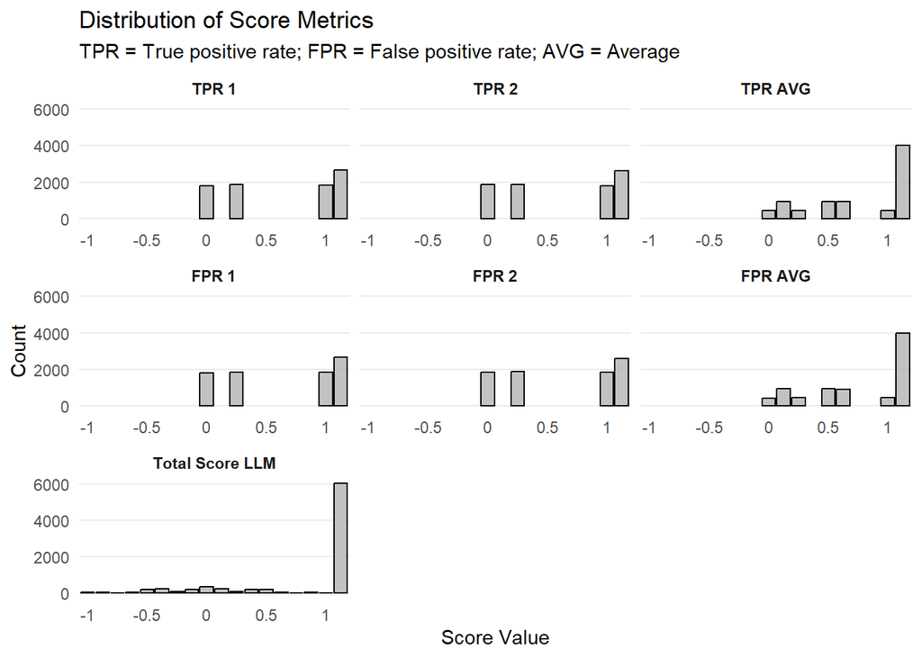

```r
###! If I have no inference for this plot, should I even include them?
paper_llm_scores <- bar_function(
  dataset      = paper_llm_processed,
  base_cols    = BASE_SCORE_COLS,
  total_col    = TOTAL_SCORE_COL,
  clean_labels = CLEAN_SCORE_COLS
)

paper_llm_scores
```

## Distribution human scores

This plot does not have any inference criteria. The only purpose of this plot is to see how scores are distributed generally.

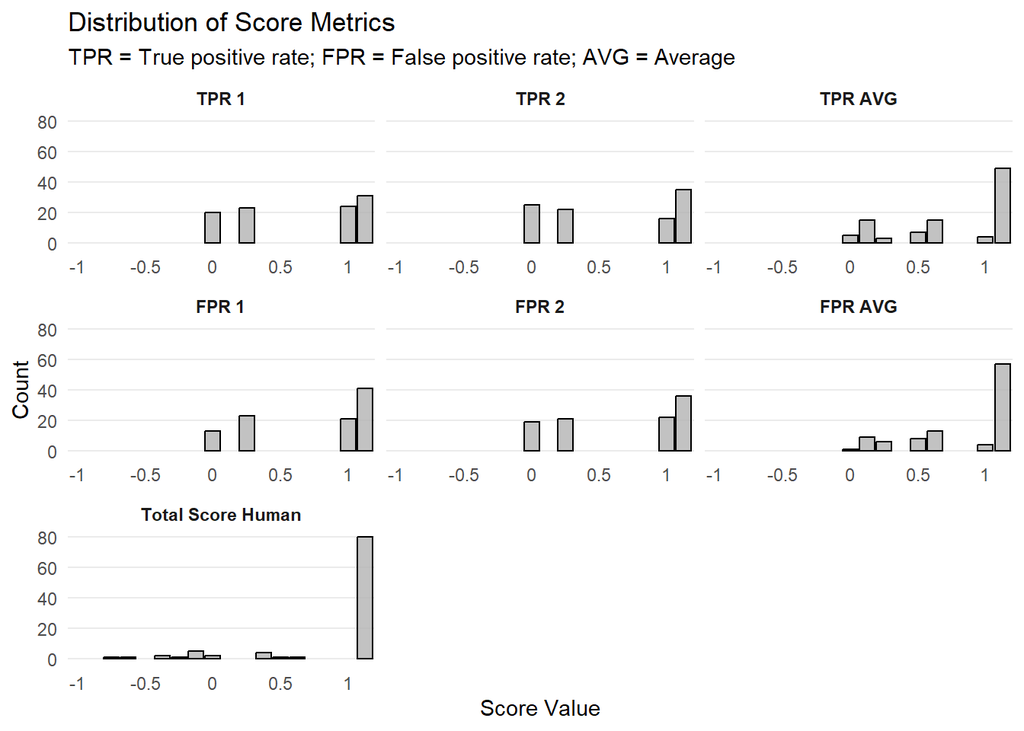

```r
paper_human_scores <- bar_function(
  dataset      = paper_human_processed,
  base_cols    = BASE_SCORE_COLS,
  total_col    = TOTAL_SCORE_COL,
  clean_labels = CLEAN_SCORE_COLS,
  suffix = "_human",
)

paper_human_scores
```

## Success rate

```r
success_spec_plot <- data_plot |>
  # Preprocess
  dplyr::select(
    `Model`,
    `Hyper-<br> parameter`,
    `CoT<br> used`,
    `Scope`,
    success_rate,
    boot_success_lower,
    boot_success_upper
  ) |>
  # Summarize
  group_by(Model, `Hyper-<br> parameter`, `CoT<br> used`, Scope) |>
  summarise(
    success_rate = mean(success_rate),
    boot_success_lower = mean(boot_success_lower),
    boot_success_upper = mean(boot_success_upper),
    .groups = "drop"
  ) |>
  arrange(success_rate) |>
  mutate(rank = row_number()) |>
  # Plot call
  specification_curve_plot_with_shading(
  outcome = success_rate,
  outcome_name = "Success rate TVD-MI",
  outcome_cutoff = 1.0,
  plot_title = "Specification Curve: Success rate by Configuration",
  interval_lower = "boot_success_lower",
  interval_upper = "boot_success_upper",
  rank_by = rank,

  mutate_plots = \(top, bottom, df) {
    list(top + coord_cartesian(ylim = c(0, 1)))
  }
)
```

This plot shows for how many papers in a given parameter combination the review generation was successful.

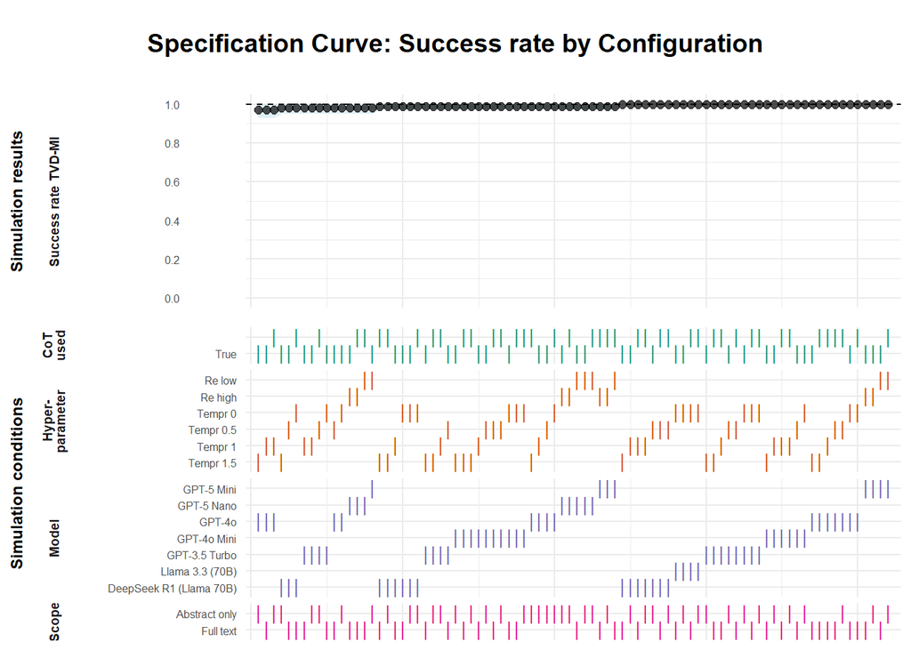

```r
success_spec_plot
```

## Mean

```r
###! The quality assessment ignores how many unsuccessful combos a configuration had. I have included this information via the transparency of the data point (alpha). Should I keep or drop this?

mean_spec_plot <- data_plot |>
  # Preprocess
  dplyr::select(
    `Model`,
    `Hyper-<br> parameter`,
    `CoT<br> used`,
    `Scope`,
    group_mean,
    success_rate,
    boot_mean_lower,
    boot_mean_upper,
    boot_mean_lower_human,
    boot_mean_upper_human
  ) |>
  # Summarize
  group_by(Model, `Hyper-<br> parameter`, `CoT<br> used`, Scope) |>
  summarize(
    group_mean = mean(group_mean),
    success_rate = mean(success_rate),
    boot_mean_lower = mean(boot_mean_lower),
    boot_mean_upper = mean(boot_mean_upper),
    boot_mean_lower_human = mean(boot_mean_lower_human),
    boot_mean_upper_human = mean(boot_mean_upper_human),
    .groups = "drop"
  ) |>
  arrange(group_mean) |>
  mutate(rank = row_number()) |>
  # Plot call
  specification_curve_plot_with_shading(
    # Basic content
    outcome = group_mean,
    outcome_name = "Mean TVD-MI score",
    plot_title = "Specification Curve: Mean by Configuration",
    interval_lower = "boot_mean_lower",
    interval_upper = "boot_mean_upper",
    is_processed = success_rate,
    rank_by = rank,
    # CI base
    shade_lower = "boot_mean_lower_human",
    shade_upper = "boot_mean_upper_human",

    mutate_plots = \(top, bottom, df) {
      list(top + coord_cartesian(ylim = c(-1, 1)))
    }
  )
```

This plot indicates the average quality of LLM-authored reviews for each parameter combination. Note that this plot does not consider for how many of the papers the parameter combination yielded a review in the first place.

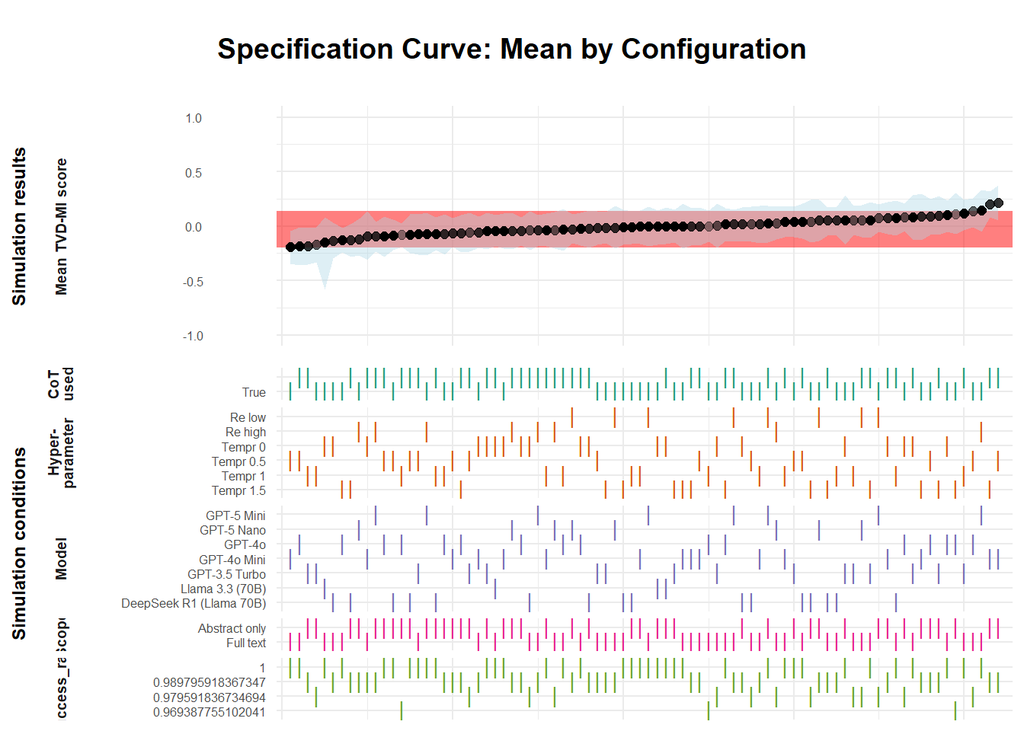

```r
mean_spec_plot
```

# Inferential tests

```r
# Function for conditional posthoc tests
conditional_posthoc_function <- function(model, alpha = 0.05, adjust = "bonferroni") {

  # Check if model is binomial (glmer) or linear (lmer)
  is_glmer <- inherits(model, "glmerMod")
  test_stat <- if(is_glmer) "Chisq" else "F"

  anova_res <- tryCatch({
    car::Anova(model, type = "II", test.statistic = test_stat)
  }, error = function(e) {
    message("ANOVA failed: ", e$message)
    return(NULL)
  })

  if(is.null(anova_res)) return(NULL)

  # Identify the p-value column (it's either Pr(>Chisq) or Pr(>F))
  p_col <- grep("Pr\\(>", colnames(anova_res), value = TRUE)

  # Handle cases where no terms are significant
  sig_mask <- anova_res[[p_col]] < alpha
  terms <- rownames(anova_res)[sig_mask]
  terms <- terms[!terms %in% c("(Intercept)", "Residuals")]

  if(length(terms) == 0) {
    message("No significant terms found at alpha ", alpha)
    return(list(anova = anova_res, posthoc = list()))
  }

  # Run post-hoc tests
  results <- lapply(terms, function(term) {

    spec_formula <- as.formula(paste("~", term))

    # Calculate Estimated Marginal Means
    emm <- emmeans::emmeans(model, specs = spec_formula, type = "response")

    # Compact Letter Display (CLD)
    multcomp::cld(emm,
                  alpha = alpha,
                  Letters = c(letters, LETTERS),
                  adjust = adjust,
                  reversed = TRUE) |>
      as.data.frame() |>
      mutate(term = term)
  })

  names(results) <- terms
  return(list(anova = anova_res, posthoc = results))
}
```

```r
###! By default the function deletes any combo which includes NAs. This can lead to bias, benefitial for combos with a small amount of kept rows, as my data is not missing at random. Can I still run them like this?

lmm_mean_total <- lme4::lmer(tvd_mi_score ~ model + hyperparameter + chain_of_thought + scope + (1 | paper_id),
                             data = paper_llm_processed)
posthoc_mean_total <- conditional_posthoc_function(lmm_mean_total, alpha = ALPHA, adjust = POST_HOC_CORRECTION)
```

```r
posthoc_mean_total
```

```
$anova
Analysis of Deviance Table (Type II Wald F tests with Kenward-Roger df)

Response: tvd_mi_score
                      F Df Df.res Pr(>F)
model            0.5921  6 2121.8 0.7369
hyperparameter   1.0852  4 2121.6 0.3622
chain_of_thought 0.2005  1 2128.0 0.6544
scope            0.4535  1 2119.5 0.5008

$posthoc
list()
```

# References

Cummins, J. (2025). *The threat of analytic flexibility in using large language models to simulate human data: A call to attention* (arXiv:2509.13397). arXiv. https://doi.org/10.48550/arXiv.2509.13397